# **TRABAJO GRUPAL 3**

# EJERCICIO 1:

Use two maps of points from your country.

Compute the distance matrix for both maps.

Select one row of the distance matrix, and plot the two points with the minimal distance on top of the country of your choosing.

```python
#!pip install fiona
```

[output not shown]

```python
from  fiona import listlayers

AustraliaMapsLink='https://github.com/valcc01/Trabajo-grupal-3/raw/refs/heads/main/GEODATA/australiaMaps_3112(1).gpkg'

#layers in maps
listlayers(AustraliaMapsLink)
```

```
['country', 'cities', 'rivers', 'airports']
```

```python
import os, geopandas as gpd

australia_municipalities=gpd.read_file("https://github.com/valcc01/Trabajo-grupal-3/raw/refs/heads/main/SUBNATIONAL/SA4_2021_AUST_SHP_GDA2020/SA4_2021_AUST_GDA2020.shp")
australia_states=gpd.read_file("https://github.com/valcc01/Trabajo-grupal-3/raw/refs/heads/main/SUBNATIONAL/STE_2021_AUST_SHP_GDA2020/STE_2021_AUST_GDA2020.shp")
```

```python
airports=gpd.read_file(AustraliaMapsLink,layer='airports')
rivers=gpd.read_file(AustraliaMapsLink,layer='rivers')
```

```python
import pandas as pd

portsFileLink="https://github.com/CienciaDeDatosEspacial/GeoDataFrame_Analytics/raw/main/data/UpdatedPub150.csv"
infoseaports=pd.read_csv(portsFileLink)
```

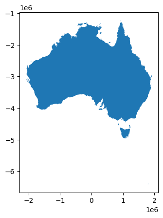

```python
countries=gpd.read_file(os.path.join("https://github.com/RenzoJSC/introgeodf/raw/refs/heads/main/maps/World_Countries/World_Countries.shp"))
australia=countries[countries.COUNTRY=='Australia']
australia_3112=australia.to_crs(3112)
australia_3112.plot()
```

```python
#rename
infoseaports.rename(columns={'Main Port Name':'portName'},inplace=True)
#keep few columns
infoseaports=infoseaports.loc[:,['portName', 'Country Code','Latitude', 'Longitude']]

# we have now
infoseaports.head()
```

|  | portName | Country Code | Latitude | Longitude |
| --- | --- | --- | --- | --- |
| 0 | Maurer | United States | 40.533333 | -74.250000 |
| 1 | Mangkasa Oil Terminal | Indonesia | -2.733333 | 121.066667 |
| 2 | Iharana | Madagascar | -13.350000 | 50.000000 |
| 3 | Andoany | Madagascar | -13.400000 | 48.300000 |
| 4 | Chake Chake | Tanzania | -5.250000 | 39.766667 |

```python
#spatial points (unprojected)
seaports=gpd.GeoDataFrame(data=infoseaports.copy(),
                           geometry=gpd.points_from_xy(infoseaports.Longitude,
                                                       infoseaports.Latitude),
                          crs=4326)# notice it is unprojected

# keep australia
seaports_australia=seaports[seaports['Country Code']=='Australia'].copy()

# reset indexes
seaports_australia.reset_index(drop=True, inplace=True)

# reprojecting
seaports_australia_3112=seaports_australia.to_crs(3112) # projected crs
```

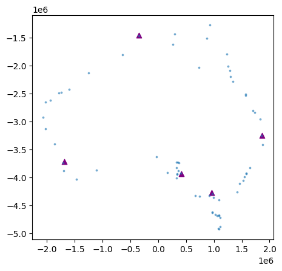

```python
# subsetting
largeAirports=airports[airports['kind']=='large_airport'] #can't use "airports.type"
largeAirports.reset_index(drop=True, inplace=True)

#plotting
base=largeAirports.plot(color='purple',marker="^")
seaports_australia_3112.plot(ax=base,alpha=0.5,markersize=3)
```

```python
seaports_australia_3112.head()
```

|  | portName | Country Code | Latitude | Longitude | geometry |
| --- | --- | --- | --- | --- | --- |
| 0 | Dover | Australia | -43.316667 | 147.033333 | POINT (1087783.364 -4930315.345) |
| 1 | Burnie | Australia | -41.050000 | 145.950000 | POINT (1022145.796 -4664513.364) |
| 2 | Ballina | Australia | -28.866667 | 153.566667 | POINT (1878859.725 -3411689.117) |
| 3 | Beauty Point | Australia | -41.150000 | 146.816667 | POINT (1094875.552 -4683076.964) |
| 4 | Lucinda | Australia | -18.516667 | 146.333333 | POINT (1298466.288 -2193115.291) |

```python
largeAirports.head()
```

|  | name | kind | latitude_deg | longitude_deg | elevation_ft | region_name | municipality | geometry |
| --- | --- | --- | --- | --- | --- | --- | --- | --- |
| 0 | Melbourne International Airport | large_airport | -37.673302 | 144.843002 | 434.0 | Victoria | Melbourne | POINT (960390.027 -4278051.009) |
| 1 | Brisbane International Airport | large_airport | -27.384199 | 153.117004 | 13.0 | Queensland | Brisbane | POINT (1860613.688 -3244612.198) |
| 2 | Perth International Airport | large_airport | -31.940300 | 115.967003 | 67.0 | Western Australia | Perth | POINT (-1684432.427 -3723348.148) |
| 3 | Adelaide International Airport | large_airport | -34.947512 | 138.533393 | 20.0 | South Australia | Adelaide | POINT (412864.26 -3941270.535) |
| 4 | Darwin International Airport / RAAF Darwin | large_airport | -12.414970 | 130.881850 | 103.0 | Northern Territory | Darwin | POINT (-345664.176 -1452918.314) |

```python
# distance between 'Melbourne International Airport' and 'Dover'
largeAirports.iloc[0].geometry.distance(seaports_australia_3112.iloc[0].geometry)/1000  # in km
```

```
664.5884634412342
```

```python
seaports_australia_3112.set_index('portName').geometry.apply\
(lambda g: largeAirports.set_index('name').geometry.distance(g)/1000).\
sort_index(axis=0).sort_index(axis=1)
```

| name portName | Adelaide International Airport | Brisbane International Airport | Darwin International Airport / RAAF Darwin | Melbourne International Airport | Perth International Airport |
| --- | --- | --- | --- | --- | --- |
| Albany | 1878.175154 | 3416.684096 | 2815.472432 | 2435.182019 | 384.225804 |
| Ardrossan | 80.019657 | 1631.980784 | 2529.626327 | 720.204830 | 2049.116205 |
| Ballina | 1558.717159 | 168.070267 | 2963.998927 | 1262.604259 | 3576.895625 |
| Batemans Bay | 1058.736672 | 955.463941 | 3212.250154 | 524.785710 | 3166.158422 |
| Beauty Point | 1007.678609 | 1629.581473 | 3536.817723 | 426.769704 | 2940.345598 |
| ... | ... | ... | ... | ... | ... |
| Weipa | 2479.501024 | 2002.647513 | 1216.555606 | 2775.291569 | 3383.577441 |
| Welshpool | 823.014372 | 1392.130776 | 3284.246655 | 183.551229 | 2859.408875 |
| Western Port | 709.393357 | 1413.245949 | 3195.164448 | 83.093169 | 2746.504332 |
| Whyalla | 228.614239 | 1602.636024 | 2373.292327 | 835.298205 | 2016.826775 |
| Wyndham | 2379.967832 | 2883.121141 | 458.109525 | 2943.872306 | 2184.598814 |

66 rows × 5 columns

```python
import geopandas as gpd
from shapely.geometry import Point

#Encontrando entre qué puerto y aeropuerta corresponde la menor distancia
distance_matrix = seaports_australia_3112.set_index('portName').geometry.apply(
    lambda g: largeAirports.set_index('name').geometry.distance(g) / 1000
).sort_index(axis=0).sort_index(axis=1)

#Hallando la fila y columna con el menor valor
min_row, min_col = distance_matrix.stack().idxmin()

print(f"The minimum distance is at row '{min_row}' and column '{min_col}'")
```

```
The minimum distance is at row 'Darwin' and column 'Darwin International Airport / RAAF Darwin'
```

```
Darwin International Airport not found in the DataFrame.
```

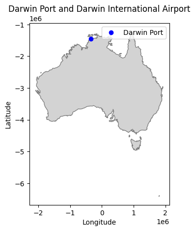

```python
import matplotlib.pyplot as plt

# Find the geometries for Darwin port and Darwin International Airport
darwin_port_geometry = seaports_australia_3112[seaports_australia_3112['portName'] == 'Darwin'].geometry.iloc[0]

# Check if the airport exists in the DataFrame before accessing it
airport_df = largeAirports[largeAirports['name'] == 'Darwin International Airport']
if not airport_df.empty:
    darwin_airport_geometry = airport_df.geometry.iloc[0]
else:
    print("Darwin International Airport not found in the DataFrame.")
    # Handle the case where the airport is not found, e.g., skip plotting or use a default value

# Plot the base map (Australia)
base = australia_3112.plot(color='lightgray', edgecolor='gray')

# Plot the port and airport if available
plt.plot(darwin_port_geometry.x, darwin_port_geometry.y, 'bo', label='Darwin Port')
if not airport_df.empty: # Only plot if airport was found
    plt.plot(darwin_airport_geometry.x, darwin_airport_geometry.y, 'r^', label='Darwin International Airport')

# Add labels and title
plt.xlabel("Longitude")
plt.ylabel("Latitude")
plt.title("Darwin Port and Darwin International Airport")
plt.legend()

plt.show()
```

```python
distanceMatrixKM_sea_air= seaports_australia_3112.set_index('portName').geometry.apply\
                          (lambda g: largeAirports.set_index('name').geometry.distance(g)/1000).\
                          sort_index(axis=0).sort_index(axis=1)
```

# **EJERCICIO 2:**

Use a map of points and a map of lines from your country.

Compute the distance matrix for both.

Select one line of the distance matrix, and plot the closests and the farthest point to that line.

```python
#Los 2 sistemas de ríos (líneas)
rivers.loc[0, 'SYSTEM'] = "Murray"
rivers.loc[1, 'SYSTEM'] = "Darling"
rivers.head()
```

|  | NAME | SYSTEM | geometry |
| --- | --- | --- | --- |
| 0 | Murray | Murray | MULTILINESTRING ((746729.373 -3859608.408, 711... |
| 1 | Darling | Darling | MULTILINESTRING ((746729.373 -3859608.408, 755... |

```python
systems=rivers.dissolve(by='SYSTEM')
systems
```

| SYSTEM | geometry | NAME |
| --- | --- | --- |
| Darling | LINESTRING (746729.373 -3859608.408, 755420.07... | Darling |
| Murray | MULTILINESTRING ((746729.373 -3859608.408, 711... | Murray |

```python
rivers[rivers.NAME.str.contains('Murray')]
```

|  | NAME | SYSTEM | geometry |
| --- | --- | --- | --- |
| 0 | Murray | Murray | MULTILINESTRING ((746729.373 -3859608.408, 711... |

```python
rivers[rivers.NAME.str.contains('Murray')].iloc[0].geometry.distance(largeAirports.set_index('name').geometry)/1000
```

| name | geometry |
| --- | --- |
| Melbourne International Airport | 178.934715 |
| Brisbane International Airport | 1053.111624 |
| Perth International Airport | 2189.213675 |
| Adelaide International Airport | 85.642665 |
| Darwin International Airport / RAAF Darwin | 2544.741190 |

**dtype:** float64

```python
distanceMatrixKM_riv_air=rivers.set_index('NAME').geometry.apply\
(lambda g: largeAirports.set_index('name').geometry.distance(g)/1000).\
sort_index(axis=0).sort_index(axis=1)
distanceMatrixKM_riv_air
```

| name NAME | Adelaide International Airport | Brisbane International Airport | Darwin International Airport / RAAF Darwin | Melbourne International Airport | Perth International Airport |
| --- | --- | --- | --- | --- | --- |
| Darling | 343.707167 | 582.232895 | 2223.359217 | 469.835169 | 2434.977321 |
| Murray | 85.642665 | 1053.111624 | 2544.741190 | 178.934715 | 2189.213675 |

```python
distanceMatrixKM_riv_air.loc['Murray'].sort_values()
```

| name | Murray |
| --- | --- |
| Adelaide International Airport | 85.642665 |
| Melbourne International Airport | 178.934715 |
| Brisbane International Airport | 1053.111624 |
| Perth International Airport | 2189.213675 |
| Darwin International Airport / RAAF Darwin | 2544.741190 |

**dtype:** float64

```python
#!pip install mapclassify folium matplotlib
```

[output not shown]

```python
import mapclassify
import folium
import matplotlib.pyplot as plt

base=largeAirports.explore(color='red',marker_kwds=dict(radius=10))
rivers[rivers.NAME.str.contains('Murray')].explore(m=base)
```

Make this Notebook Trusted to load map: File -> Trust Notebook

[interactive chart not shown]

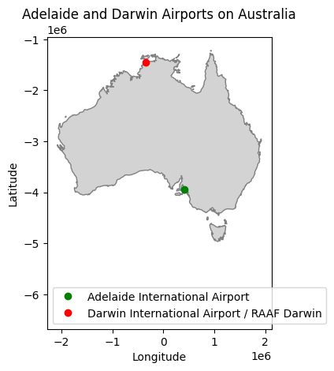

```python
# Graficando el aeropuerto (punto) más cercano (Adeleide) y más lejano (Darwin) a la línea del sistema Murray
# Find the geometries for the specified airports
adelaide_airport_geometry = largeAirports[largeAirports['name'] == 'Adelaide International Airport'].geometry.iloc[0]
darwin_airport_geometry = largeAirports[largeAirports['name'] == 'Darwin International Airport / RAAF Darwin'].geometry.iloc[0]


# Plot the base map (Australia)
base = australia_3112.plot(color='lightgray', edgecolor='gray')

# Plot the airports
plt.plot(adelaide_airport_geometry.x, adelaide_airport_geometry.y, 'go', label='Adelaide International Airport')
plt.plot(darwin_airport_geometry.x, darwin_airport_geometry.y, 'ro', label='Darwin International Airport / RAAF Darwin')


# Add labels and title
plt.xlabel("Longitude")
plt.ylabel("Latitude")
plt.title("Adelaide and Darwin Airports on Australia")
plt.legend()

plt.show()
```

# EJERCICIO 3

Create a HULL for some set of line map.

Compute the distance matrix between the HULLS and a map of points.

Plot the HULLS and the points. Show the closest and farthest points to the HULL.

```python
systems.convex_hull
```

| SYSTEM | 0 |
| --- | --- |
| Darling | POLYGON ((746729.373 -3859608.408, 755420.073 ... |
| Murray | POLYGON ((1267047.547 -4222620.703, 485782.185... |

**dtype:** geometry

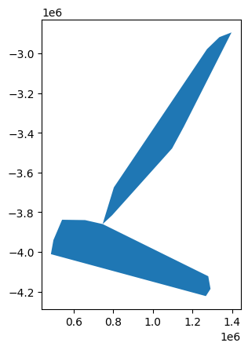

```python
#Hull de ambos sistemas de ríos
systems.convex_hull.plot()
```

```python
systems_hulls=systems.convex_hull.to_frame()
systems_hulls['system']=['Murray','Darling']
systems_hulls.rename(columns={0:'geometry'},inplace=True)
systems_hulls=systems_hulls.set_geometry('geometry')
systems_hulls.crs="EPSG:3112"
systems_hulls
```

[output not shown]

```python
distanceMatrixKM_sysHull_air=systems_hulls.set_index('system').geometry.apply\
(lambda g: largeAirports.set_index('name').geometry.distance(g)/1000).\
sort_index(axis=0).sort_index(axis=1)

distanceMatrixKM_sysHull_air
```

| name system | Adelaide International Airport | Brisbane International Airport | Darwin International Airport / RAAF Darwin | Melbourne International Airport | Perth International Airport |
| --- | --- | --- | --- | --- | --- |
| Darling | 84.095757 | 1053.111624 | 2544.741190 | 133.629689 | 2189.213675 |
| Murray | 343.707167 | 572.895495 | 2223.359217 | 469.835169 | 2434.977321 |

[figure not shown]

[figure not shown]

```python
# Graficamos Hull Murray con su aeropuerto más cerca y lejano. Lo mismo para Hull Darling

import matplotlib.pyplot as plt

# ... (Your existing code) ...


def plot_closest_farthest_airports(hull_system, distance_matrix):
    """Plots the closest and farthest airports to a given river system hull."""

    # Find the closest and farthest airports to the hull
    closest_airport = distance_matrix.loc[hull_system].idxmin()
    farthest_airport = distance_matrix.loc[hull_system].idxmax()
    closest_distance = distance_matrix.loc[hull_system].min()
    farthest_distance = distance_matrix.loc[hull_system].max()

    # Get the geometries for the closest and farthest airports
    closest_airport_geometry = largeAirports[largeAirports['name'] == closest_airport].geometry.iloc[0]
    farthest_airport_geometry = largeAirports[largeAirports['name'] == farthest_airport].geometry.iloc[0]

    # Plot the base map (Australia)
    base = australia_3112.plot(color='lightgray', edgecolor='gray')

    # Plot the hull
    systems_hulls[systems_hulls['system'] == hull_system].plot(ax=base, color='orange', edgecolor='black', alpha=0.5, label=f'{hull_system} Hull')

    # Plot the closest and farthest airports
    plt.plot(closest_airport_geometry.x, closest_airport_geometry.y, 'go', label=f'Closest Airport: {closest_airport} ({closest_distance:.2f} km)')
    plt.plot(farthest_airport_geometry.x, farthest_airport_geometry.y, 'ro', label=f'Farthest Airport: {farthest_airport} ({farthest_distance:.2f} km)')

    # Add labels and title
    plt.xlabel("Longitude")
    plt.ylabel("Latitude")
    plt.title(f"Closest and Farthest Airports to {hull_system} River System Hull")
    plt.legend()

    plt.show()


# Example usage for the Murray-Darling systems
plot_closest_farthest_airports('Murray', distanceMatrixKM_sysHull_air)
plot_closest_farthest_airports('Darling', distanceMatrixKM_sysHull_air)
```

# EJERCICIO 4:

Select a line map and a point one.

Get the buffer for the lines, select a distance.

Keep the points that are within the buffer (you might need to play with differn distances until you show something interesting.

```python
distanceMatrixKM_riv_air
```

| name NAME | Adelaide International Airport | Brisbane International Airport | Darwin International Airport / RAAF Darwin | Melbourne International Airport | Perth International Airport |
| --- | --- | --- | --- | --- | --- |
| Darling | 343.707167 | 582.232895 | 2223.359217 | 469.835169 | 2434.977321 |
| Murray | 85.642665 | 1053.111624 | 2544.741190 | 178.934715 | 2189.213675 |

```python
distanceMatrixKM_riv_air.loc['Darling'].min() # I chose min
```

```
343.7071671041337
```

```python
minMts=distanceMatrixKM_riv_air.loc['Darling'].min()*50 # km

#the buffer is a polygon:
rivers[rivers.NAME=='Darling'].buffer(distance = minMts)
```

|  | 0 |
| --- | --- |
| 1 | POLYGON ((738949.989 -3825528.629, 739527.24 -... |

**dtype:** geometry

```python
bufferAroundDarling=rivers[rivers.NAME=='Darling'].buffer(distance = minMts)
bufferAsBase=bufferAroundDarling.explore(color='red')
rivers[rivers.NAME=='Darling'].explore(m=bufferAsBase,color='blue',style_kwds={'weight':1.0})
```

Make this Notebook Trusted to load map: File -> Trust Notebook

[interactive chart not shown]

```python
small_airports=airports[airports['kind']=='small_airport']

# plotting
rivers[rivers.NAME=='Amazon'].explore(m=bufferAsBase,color='purple',style_kwds={'weight':0.5})
small_airports.explore(m=bufferAsBase,color='black')
```

Make this Notebook Trusted to load map: File -> Trust Notebook

[interactive chart not shown]

```python
riversWithinBuffer=small_airports.clip(mask=bufferAroundDarling)
riversWithinBuffer
```

|  | name | kind | latitude_deg | longitude_deg | elevation_ft | region_name | municipality | geometry |
| --- | --- | --- | --- | --- | --- | --- | --- | --- |
| 969 | Pooncarie Airport | small_airport | -33.373263 | 142.586439 | 50.0 | New South Wales | None | POINT (793410.715 -3787116.882) |
| 2087 | Whurlie Station Airport | small_airport | -33.023682 | 142.347431 | NaN | New South Wales | Pooncarie | POINT (773915.094 -3747198.354) |
| 1957 | Menindee Airport | small_airport | -32.944155 | 142.392727 | NaN | New South Wales | Menindee | POINT (778692.855 -3738739.425) |
| 1958 | Menindee Number 2 Airport | small_airport | -32.847423 | 142.476044 | 214.0 | New South Wales | Menindee | POINT (787129.321 -3728631.407) |
| 1964 | Tolarno Station South Airport | small_airport | -32.830738 | 142.393456 | 194.0 | New South Wales | Menindee | POINT (779593.834 -3726283.775) |
| 1962 | Menindee Number 3 Airport | small_airport | -32.624012 | 142.441130 | 200.0 | New South Wales | Menindee | POINT (785542.47 -3703876.721) |
| 1961 | Bono Station Airport | small_airport | -32.565419 | 142.402085 | NaN | New South Wales | Menindee | POINT (782345.09 -3697199.741) |
| 1585 | Barraroo Airstrip | small_airport | -32.117535 | 142.982026 | NaN | New South Wales | Barraroo | POINT (839774.337 -3651795.326) |
| 1960 | four mile lake airstrip | small_airport | -32.087571 | 142.894764 | NaN | New South Wales | Menindee | POINT (831862.457 -3647928.789) |
| 1913 | Louth Airport | small_airport | -30.531414 | 145.128413 | NaN | New South Wales | Louth | POINT (1055380.796 -3494347.368) |
| 2223 | Murtee Station | small_airport | -31.576524 | 143.496093 | NaN | New South Wales | Wilcannia | POINT (892236.569 -3596039.911) |
| 936 | Wilcannia Airport | small_airport | -31.522082 | 143.378358 | 250.0 | New South Wales | None | POINT (881640.949 -3589245.366) |
| 2176 | Tilpa Airport | small_airport | -30.925497 | 144.419403 | NaN | New South Wales | Tilpa | POINT (984719.133 -3531674.423) |
| 1570 | Attica State Forest Airstrip | small_airport | -25.244083 | 147.381276 | NaN | Queensland | Attica State Forest | POINT (1329830.352 -2939446.895) |
| 1013 | Engonnia Airport | small_airport | -29.311175 | 145.857475 | NaN | New South Wales | None | POINT (1136926.451 -3367495.382) |
| 1757 | Enngonia station | small_airport | -29.069393 | 145.998774 | NaN | New South Wales | Enngonia NSW 2839 | POINT (1152958.764 -3342414.251) |
| 767 | Wyandra Airport | small_airport | -27.266701 | 145.990005 | 244.0 | Queensland | None | POINT (1170920.897 -3145860.673) |

```python
bufferAsBase=bufferAroundDarling.explore(color='red')
rivers[rivers.NAME=='Darling'].explore(m=bufferAsBase,color='blue',style_kwds={'weight':0.5})
riversWithinBuffer.explore(m=bufferAsBase,color='black')
```

Make this Notebook Trusted to load map: File -> Trust Notebook

[interactive chart not shown]

```python
distanceMatrixKM_riv_air.min(axis=1).min()
```

```
85.6426650255539
```

```python
minMinMts_5=5*distanceMatrixKM_riv_air.min(axis=1).min()*50


allMinBuffer=rivers.buffer(distance = minMinMts_5).explore(color='red')
rivers.explore(m=allMinBuffer,color='blue',style_kwds={'weight':0.5})
```

Make this Notebook Trusted to load map: File -> Trust Notebook

[interactive chart not shown]

```python
riversAll_buf=rivers.buffer(distance = minMinMts_5)
riversAll_buf
```

|  | 0 |
| --- | --- |
| 0 | POLYGON ((503755.858 -3916912.864, 503747.367 ... |
| 1 | POLYGON ((734900.543 -3824322.306, 735619.721 ... |

**dtype:** geometry

```python
allRiversWithinBuffs=small_airports.clip(riversAll_buf)
allRiversWithinBuffs
```

|  | name | kind | latitude_deg | longitude_deg | elevation_ft | region_name | municipality | geometry |
| --- | --- | --- | --- | --- | --- | --- | --- | --- |
| 2104 | Robinvale Airport | small_airport | -34.642887 | 142.773042 | 87.0 | Victoria | Robinvale | POINT (800850.885 -3928100.556) |
| 2186 | Trentham Cliffs airstrip | small_airport | -34.234051 | 142.267845 | NaN | New South Wales | Trentham Cliffs | POINT (757771.974 -3879900.604) |
| 627 | Wentworth Airport | small_airport | -34.088299 | 141.891998 | 37.0 | New South Wales | Wentworth | POINT (724380.823 -3861624.738) |
| 969 | Pooncarie Airport | small_airport | -33.373263 | 142.586439 | 50.0 | New South Wales | None | POINT (793410.715 -3787116.882) |
| 1711 | Cullulleraine airstrip private | small_airport | -34.190506 | 141.615314 | NaN | Victoria | Cullulleraine | POINT (698333.18 -3871321.393) |
| 872 | Barmera Airport | small_airport | -34.234690 | 140.476792 | NaN | South Australia | None | POINT (593778.633 -3870339.81) |
| 2026 | Neds Corner Airport | small_airport | -34.146405 | 141.334734 | NaN | Victoria | Neds Corner | POINT (672917.484 -3864929.883) |
| 150 | Waikerie Airport | small_airport | -34.179573 | 140.033026 | 138.0 | South Australia | None | POINT (553419.577 -3862235.626) |
| 2087 | Whurlie Station Airport | small_airport | -33.023682 | 142.347431 | NaN | New South Wales | Pooncarie | POINT (773915.094 -3747198.354) |
| 1957 | Menindee Airport | small_airport | -32.944155 | 142.392727 | NaN | New South Wales | Menindee | POINT (778692.855 -3738739.425) |
| 1958 | Menindee Number 2 Airport | small_airport | -32.847423 | 142.476044 | 214.0 | New South Wales | Menindee | POINT (787129.321 -3728631.407) |
| 1964 | Tolarno Station South Airport | small_airport | -32.830738 | 142.393456 | 194.0 | New South Wales | Menindee | POINT (779593.834 -3726283.775) |
| 1959 | Bindara Airstrip | small_airport | -32.736805 | 142.355986 | NaN | New South Wales | Menindee | POINT (776805.767 -3715734.101) |
| 1962 | Menindee Number 3 Airport | small_airport | -32.624012 | 142.441130 | 200.0 | New South Wales | Menindee | POINT (785542.47 -3703876.721) |
| 1961 | Bono Station Airport | small_airport | -32.565419 | 142.402085 | NaN | New South Wales | Menindee | POINT (782345.09 -3697199.741) |
| 1955 | Menindee Airport | small_airport | -32.366699 | 142.404999 | NaN | New South Wales | Menindee | POINT (784077.145 -3675403.73) |
| 1585 | Barraroo Airstrip | small_airport | -32.117535 | 142.982026 | NaN | New South Wales | Barraroo | POINT (839774.337 -3651795.326) |
| 1960 | four mile lake airstrip | small_airport | -32.087571 | 142.894764 | NaN | New South Wales | Menindee | POINT (831862.457 -3647928.789) |
| 589 | Meningie Airport | small_airport | -35.701002 | 139.345522 | NaN | South Australia | Meningie | POINT (483236.79 -4027546.36) |
| 2125 | Sherlock Ultralight Airfield | small_airport | -35.320278 | 139.792522 | 58.0 | South Australia | Sherlock | POINT (525561.941 -3987197.181) |
| 613 | Swan Reach Airport | small_airport | -34.556053 | 139.592156 | 36.0 | South Australia | Swan Reach | POINT (511155.569 -3901912.551) |
| 276 | Loxton Airport | small_airport | -34.474998 | 140.662994 | 38.0 | South Australia | None | POINT (609426.714 -3897740.185) |
| 577 | Jindabyne Airport | small_airport | -36.429087 | 148.599722 | 3400.0 | New South Wales | Jindabyne | POINT (1307883.406 -4174127.952) |
| 963 | Khancoban Airport | small_airport | -36.215920 | 148.113743 | NaN | New South Wales | None | POINT (1267187.817 -4145627.116) |
| 1648 | Cabramurra Airport | small_airport | -35.926888 | 148.392548 | NaN | New South Wales | Cabramurra Township | POINT (1295777.231 -4116598.499) |
| 2187 | Tumbarumba Airport | small_airport | -35.762604 | 147.886885 | 1993.0 | New South Wales | Tumbarumba | POINT (1252449.985 -4093366.69) |
| 93 | Yarrawonga Airport | small_airport | -36.028900 | 146.029007 | 423.0 | Victoria | None | POINT (1082617.757 -4105488.7) |
| 285 | Tocumwal Airport | small_airport | -35.811699 | 145.608002 | 372.0 | New South Wales | None | POINT (1047059.236 -4077933.154) |
| 1595 | Berrigan Airstrip | small_airport | -35.684209 | 145.814753 | NaN | New South Wales | Berrigan | POINT (1066980.998 -4065597.85) |
| 951 | Finley Airport | small_airport | -35.658918 | 145.561214 | 380.0 | New South Wales | None | POINT (1044406.984 -4060676.572) |
| 1038 | Moama Airstrip | small_airport | -36.074459 | 144.764485 | 310.0 | New South Wales | None | POINT (968672.377 -4100203.665) |
| 1913 | Louth Airport | small_airport | -30.531414 | 145.128413 | NaN | New South Wales | Louth | POINT (1055380.796 -3494347.368) |
| 2223 | Murtee Station | small_airport | -31.576524 | 143.496093 | NaN | New South Wales | Wilcannia | POINT (892236.569 -3596039.911) |
| 936 | Wilcannia Airport | small_airport | -31.522082 | 143.378358 | 250.0 | New South Wales | None | POINT (881640.949 -3589245.366) |
| 2176 | Tilpa Airport | small_airport | -30.925497 | 144.419403 | NaN | New South Wales | Tilpa | POINT (984719.133 -3531674.423) |
| 774 | Augathella Airport | small_airport | -25.754999 | 146.587006 | NaN | Queensland | None | POINT (1245576.001 -2986938.575) |
| 1570 | Attica State Forest Airstrip | small_airport | -25.244083 | 147.381276 | NaN | Queensland | Attica State Forest | POINT (1329830.352 -2939446.895) |
| 1576 | Upper Warrego Airstrip | small_airport | -25.194258 | 147.142757 | 1696.0 | Queensland | Babbiloora | POINT (1306783.041 -2931520.385) |
| 799 | Torres Park Homestead Airport | small_airport | -25.116699 | 147.167007 | NaN | Queensland | None | POINT (1310073.469 -2923328.099) |
| 1611 | Bourke no.2 | small_airport | -30.014772 | 145.826780 | NaN | New South Wales | Bourke | POINT (1126745.821 -3443988.829) |
| 1013 | Engonnia Airport | small_airport | -29.311175 | 145.857475 | NaN | New South Wales | None | POINT (1136926.451 -3367495.382) |
| 1757 | Enngonia station | small_airport | -29.069393 | 145.998774 | NaN | New South Wales | Enngonia NSW 2839 | POINT (1152958.764 -3342414.251) |
| 767 | Wyandra Airport | small_airport | -27.266701 | 145.990005 | 244.0 | Queensland | None | POINT (1170920.897 -3145860.673) |
| 1518 | Rosevale Resort Airport | small_airport | -27.133301 | 145.899994 | NaN | Queensland | None | POINT (1163537.399 -3130490.091) |

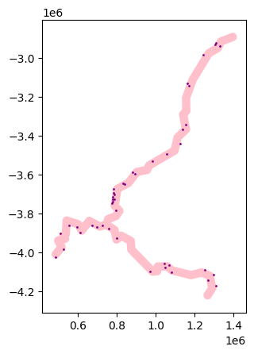

```python
base=riversAll_buf.plot(color='pink')
allRiversWithinBuffs.plot(ax=base, color='purple', markersize=1)
```

```python
base=riversAll_buf.explore(color='pink')
allRiversWithinBuffs.explore(m=base, color='purple')
```

Make this Notebook Trusted to load map: File -> Trust Notebook

[interactive chart not shown]

# EJERCICIO 5:

Get a polygons map of the lowest administrative unit possible.

Get a table of variables for those units. At least 3 numerical variables.

Preprocess both tables and get them ready for merging.

Do the merging, making the changes needed so that you keep the most columns.

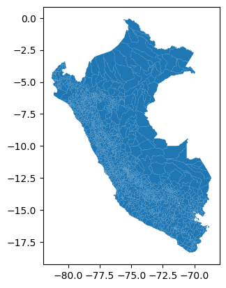

```python
import geopandas as gpd

peruMapaDistLink="https://github.com/CienciaDeDatosEspacial/GeoDataFrame_Analytics/raw/main/maps/DistritosMap.zip"

mapdis=gpd.read_file(peruMapaDistLink)

mapdis.plot()
```

```python
mapdis
```

|  | DEPARTAMEN | PROVINCIA | DISTRITO | INSTITUCIO | geometry |
| --- | --- | --- | --- | --- | --- |
| 0 | TACNA | TACNA | CORONEL GREGORIO ALBARRACIN LANCHIPA | IGN | POLYGON ((-70.17413 -18.12896, -70.17461 -18.1... |
| 1 | TACNA | TACNA | POCOLLAY | IGN | POLYGON ((-69.93475 -17.92557, -69.90467 -17.9... |
| 2 | TACNA | TACNA | CALANA | IGN | POLYGON ((-70.11604 -17.91106, -70.11457 -17.9... |
| 3 | TACNA | TACNA | TACNA | IGN | POLYGON ((-70.3149 -17.94498, -70.30682 -17.95... |
| 4 | TACNA | TACNA | SAMA | IGN | POLYGON ((-70.42497 -17.88934, -70.48022 -17.9... |
| ... | ... | ... | ... | ... | ... |
| 1869 | LIMA | LIMA | CIENEGUILLA | IGN | POLYGON ((-76.72917 -11.99948, -76.72596 -11.9... |
| 1870 | LIMA | LIMA | ANCON | IGN | POLYGON ((-77.06501 -11.57523, -77.06499 -11.5... |
| 1871 | LIMA | LIMA | CARABAYLLO | IGN | POLYGON ((-76.89892 -11.72963, -76.89768 -11.7... |
| 1872 | CALLAO | CALLAO | MI PERU | IGN | POLYGON ((-77.11491 -11.84189, -77.1145 -11.84... |
| 1873 | LIMA | LIMA | SANTIAGO DE SURCO | IGN | POLYGON ((-76.95742 -12.07604, -76.95741 -12.0... |

1874 rows × 5 columns

```python
import pandas as pd
import os

peruDataLink="https://github.com/CienciaDeDatosEspacial/GeoDataFrame_Analytics/raw/main/data/dataPeru_indicadores.xlsx"
datadis=pd.read_excel(peruDataLink,
                     dtype={'Ubigeo': object})
datadis
```

|  | Ubigeo | Departamento | Provincia | Distrito | Poblacion | Superficie | IDH2019 | Educ_sec_comp2019_pct | NBI2017_pct | Viv_sin_serv_hig2017_pct |
| --- | --- | --- | --- | --- | --- | --- | --- | --- | --- | --- |
| 0 | 010202 | Amazonas | Bagua | ARAMANGO | 10940 | 809.07 | 0.361182 | 37.545885 | 62.9 | 9.1 |
| 1 | 010201 | Amazonas | Bagua | BAGUA | 26091 | 150.99 | 0.584063 | 70.795501 | 25.4 | 0.7 |
| 2 | 010203 | Amazonas | Bagua | COPALLIN | 6319 | 99.05 | 0.467245 | 52.571361 | 45.4 | 2.1 |
| 3 | 010204 | Amazonas | Bagua | EL PARCO | 1492 | 18.48 | 0.489049 | 70.215409 | 59.9 | 1.5 |
| 4 | 010205 | Amazonas | Bagua | IMAZA | 24323 | 4430.84 | 0.298089 | 31.295719 | 88.4 | 11.7 |
| ... | ... | ... | ... | ... | ... | ... | ... | ... | ... | ... |
| 1869 | 250303 | Ucayali | Padre Abad | CURIMANA | 8956 | 2134.04 | 0.379723 | 40.397763 | 57.1 | 13.1 |
| 1870 | 250302 | Ucayali | Padre Abad | IRAZOLA | 10830 | 998.93 | 0.387806 | 40.104714 | 59.2 | 16.4 |
| 1871 | 250304 | Ucayali | Padre Abad | NESHUYA | 8445 | 579.51 | 0.455819 | 45.883427 | 60.7 | 8.5 |
| 1872 | 250301 | Ucayali | Padre Abad | PADRE ABAD | 26614 | 4689.20 | 0.475207 | 47.177338 | 47.0 | 12.6 |
| 1873 | 250401 | Ucayali | Purus | PURUS | 4657 | 17847.76 | 0.348424 | 20.543648 | 70.7 | 46.8 |

1874 rows × 10 columns

```python
#Formatear y limpiar: Eliminando espacios y convirtiendo "Provincia" y "Distrito" en mayúscula
capitalizeColumns=lambda x: x.str.upper().str.strip()
datadis[['Provincia','Distrito']]=datadis[['Provincia','Distrito']].apply(capitalizeColumns)
mapdis[['PROVINCIA','DISTRITO']]=mapdis[['PROVINCIA','DISTRITO']].apply(capitalizeColumns)
datadis
```

|  | Ubigeo | Departamento | Provincia | Distrito | Poblacion | Superficie | IDH2019 | Educ_sec_comp2019_pct | NBI2017_pct | Viv_sin_serv_hig2017_pct |
| --- | --- | --- | --- | --- | --- | --- | --- | --- | --- | --- |
| 0 | 010202 | Amazonas | BAGUA | ARAMANGO | 10940 | 809.07 | 0.361182 | 37.545885 | 62.9 | 9.1 |
| 1 | 010201 | Amazonas | BAGUA | BAGUA | 26091 | 150.99 | 0.584063 | 70.795501 | 25.4 | 0.7 |
| 2 | 010203 | Amazonas | BAGUA | COPALLIN | 6319 | 99.05 | 0.467245 | 52.571361 | 45.4 | 2.1 |
| 3 | 010204 | Amazonas | BAGUA | EL PARCO | 1492 | 18.48 | 0.489049 | 70.215409 | 59.9 | 1.5 |
| 4 | 010205 | Amazonas | BAGUA | IMAZA | 24323 | 4430.84 | 0.298089 | 31.295719 | 88.4 | 11.7 |
| ... | ... | ... | ... | ... | ... | ... | ... | ... | ... | ... |
| 1869 | 250303 | Ucayali | PADRE ABAD | CURIMANA | 8956 | 2134.04 | 0.379723 | 40.397763 | 57.1 | 13.1 |
| 1870 | 250302 | Ucayali | PADRE ABAD | IRAZOLA | 10830 | 998.93 | 0.387806 | 40.104714 | 59.2 | 16.4 |
| 1871 | 250304 | Ucayali | PADRE ABAD | NESHUYA | 8445 | 579.51 | 0.455819 | 45.883427 | 60.7 | 8.5 |
| 1872 | 250301 | Ucayali | PADRE ABAD | PADRE ABAD | 26614 | 4689.20 | 0.475207 | 47.177338 | 47.0 | 12.6 |
| 1873 | 250401 | Ucayali | PURUS | PURUS | 4657 | 17847.76 | 0.348424 | 20.543648 | 70.7 | 46.8 |

1874 rows × 10 columns

```python
#!pip install unidecode
```

[output not shown]

```python
#Eliminar caracteres que puede causar problemas
import unidecode


byePunctuation=lambda x: unidecode.unidecode(x)
datadis[['Provincia','Distrito']]=datadis[['Provincia','Distrito']].map(byePunctuation)
mapdis[['PROVINCIA','DISTRITO']]=mapdis[['PROVINCIA','DISTRITO']].map(byePunctuation)
```

```python
#Verificar si hay duplicados
datadis.Distrito.duplicated().sum(),mapdis.DISTRITO.duplicated().sum()
```

```
(154, 152)
```

```python
#Sí hay, entonces crearmos columna con nombre únicos
datadis['provDist']=["+".join(pd) for pd in zip (datadis.Provincia,datadis.Distrito)]
mapdis['provDist']=["+".join(pd) for pd in zip (mapdis.PROVINCIA,mapdis.DISTRITO)]

datadis['provDist']
```

|  | provDist |
| --- | --- |
| 0 | BAGUA+ARAMANGO |
| 1 | BAGUA+BAGUA |
| 2 | BAGUA+COPALLIN |
| 3 | BAGUA+EL PARCO |
| 4 | BAGUA+IMAZA |
| ... | ... |
| 1869 | PADRE ABAD+CURIMANA |
| 1870 | PADRE ABAD+IRAZOLA |
| 1871 | PADRE ABAD+NESHUYA |
| 1872 | PADRE ABAD+PADRE ABAD |
| 1873 | PURUS+PURUS |

1874 rows × 1 columns

**dtype:** object

```python
#¿Cuántos no están escrito igual?
nomatch_df=set(datadis.provDist)- set(mapdis.provDist)
nomatch_gdf=set(mapdis.provDist)-set(datadis.provDist)
len(nomatch_df), len(nomatch_gdf)
```

```
(26, 26)
```

```python
#!pip install thefuzz
```

[output not shown]

```python
# Se elige reemplazar los de mayor coincidencia en nomatch_df
from thefuzz import process
[(dis,process.extractOne(dis,nomatch_gdf)) for dis in sorted(nomatch_df)]
```

```
[('ANGARAES+HUANCA-HUANCA', ('ANGARAES+HUANCA HUANCA', 100)),
 ('ANGARAES+HUAYLLAY GRANDE', ('ANGARAES+HUALLAY GRANDE', 98)),
 ('AYMARAES+CARAYBAMBA', ('AYMARAES+CARAIBAMBA', 95)),
 ('AYMARAES+HUAYLLO', ('AYMARAES+IHUAYLLO', 97)),
 ('CHINCHEROS+ANCO_HUALLO', ('CHINCHEROS+ANCO HUALLO', 100)),
 ('HUAMANGA+SAN JOSE DE TICLLAS', ('HUAMANGA+SAN JOSE  DE TICLLAS', 98)),
 ('HUARAZ+PAMPAS', ('HUARAZ+PAMPAS GRANDE', 90)),
 ('ICA+SAN JOSE DE LOS MOLINOS', ('ICA+SAN JOSE DE  LOS MOLINOS', 98)),
 ('JAUJA+MASMA CHICCHE', ('JAUJA+MASMA-CHICCHE', 100)),
 ('JAUJA+TUNAN MARCA', ('JAUJA+TUNAN-MARCA', 100)),
 ('LEONCIO PRADO+DANIEL ALOMIAS ROBLES',
  ('LEONCIO PRADO+DANIEL ALOMIA ROBLES', 99)),
 ('LIMA+PUEBLO LIBRE', ('LIMA+MAGDALENA VIEJA', 49)),
 ('PICOTA+TRES UNIDOS', ('PICOTA+TRES-UNIDOS', 100)),
 ('PIURA+26 DE OCTUBRE', ('PIURA+VEINTISEIS DE OCTUBRE', 87)),
 ('SAN MARTIN+PAPAPLAYA', ('SAN MARTIN+PAPA-PLAYA', 98)),
 ('SECHURA+RINCONADA LLICUAR', ('SECHURA+RINCONADA-LLICUAR', 100)),
 ('TACNA+LA YARADA-LOS PALOS', ('TACNA+LA YARADA LOS PALOS', 100)),
 ('TARATA+ESTIQUE-PAMPA', ('TARATA+ESTIQUE PAMPA', 100)),
 ('VILCAS HUAMAN+ACCOMARCA', ('VILCAS-HUAMAN+ACCOMARCA', 100)),
 ('VILCAS HUAMAN+CARHUANCA', ('VILCAS-HUAMAN+CARHUANCA', 100)),
 ('VILCAS HUAMAN+CONCEPCION', ('VILCAS-HUAMAN+CONCEPCION', 100)),
 ('VILCAS HUAMAN+HUAMBALPA', ('VILCAS-HUAMAN+HUAMBALPA', 100)),
 ('VILCAS HUAMAN+INDEPENDENCIA', ('VILCAS-HUAMAN+INDEPENDENCIA', 100)),
 ('VILCAS HUAMAN+SAURAMA', ('VILCAS-HUAMAN+SAURAMA', 100)),
 ('VILCAS HUAMAN+VILCAS HUAMAN', ('VILCAS-HUAMAN+VILCAS HUAMAN', 100)),
 ('VILCAS HUAMAN+VISCHONGO', ('VILCAS-HUAMAN+VISCHONGO', 100))]
```

```python
#Diccionario para reemplazar
changesDis_df={dis:process.extractOne(dis,nomatch_gdf)[0] for dis in sorted(nomatch_df)}
changesDis_df
```

```
{'ANGARAES+HUANCA-HUANCA': 'ANGARAES+HUANCA HUANCA',
 'ANGARAES+HUAYLLAY GRANDE': 'ANGARAES+HUALLAY GRANDE',
 'AYMARAES+CARAYBAMBA': 'AYMARAES+CARAIBAMBA',
 'AYMARAES+HUAYLLO': 'AYMARAES+IHUAYLLO',
 'CHINCHEROS+ANCO_HUALLO': 'CHINCHEROS+ANCO HUALLO',
 'HUAMANGA+SAN JOSE DE TICLLAS': 'HUAMANGA+SAN JOSE  DE TICLLAS',
 'HUARAZ+PAMPAS': 'HUARAZ+PAMPAS GRANDE',
 'ICA+SAN JOSE DE LOS MOLINOS': 'ICA+SAN JOSE DE  LOS MOLINOS',
 'JAUJA+MASMA CHICCHE': 'JAUJA+MASMA-CHICCHE',
 'JAUJA+TUNAN MARCA': 'JAUJA+TUNAN-MARCA',
 'LEONCIO PRADO+DANIEL ALOMIAS ROBLES': 'LEONCIO PRADO+DANIEL ALOMIA ROBLES',
 'LIMA+PUEBLO LIBRE': 'LIMA+MAGDALENA VIEJA',
 'PICOTA+TRES UNIDOS': 'PICOTA+TRES-UNIDOS',
 'PIURA+26 DE OCTUBRE': 'PIURA+VEINTISEIS DE OCTUBRE',
 'SAN MARTIN+PAPAPLAYA': 'SAN MARTIN+PAPA-PLAYA',
 'SECHURA+RINCONADA LLICUAR': 'SECHURA+RINCONADA-LLICUAR',
 'TACNA+LA YARADA-LOS PALOS': 'TACNA+LA YARADA LOS PALOS',
 'TARATA+ESTIQUE-PAMPA': 'TARATA+ESTIQUE PAMPA',
 'VILCAS HUAMAN+ACCOMARCA': 'VILCAS-HUAMAN+ACCOMARCA',
 'VILCAS HUAMAN+CARHUANCA': 'VILCAS-HUAMAN+CARHUANCA',
 'VILCAS HUAMAN+CONCEPCION': 'VILCAS-HUAMAN+CONCEPCION',
 'VILCAS HUAMAN+HUAMBALPA': 'VILCAS-HUAMAN+HUAMBALPA',
 'VILCAS HUAMAN+INDEPENDENCIA': 'VILCAS-HUAMAN+INDEPENDENCIA',
 'VILCAS HUAMAN+SAURAMA': 'VILCAS-HUAMAN+SAURAMA',
 'VILCAS HUAMAN+VILCAS HUAMAN': 'VILCAS-HUAMAN+VILCAS HUAMAN',
 'VILCAS HUAMAN+VISCHONGO': 'VILCAS-HUAMAN+VISCHONGO'}
```

```python
#Se reemplaza
datadis.replace({'provDist':changesDis_df},inplace=True)
```

```python
#Se hace el merge entre mapdis y datadis
datadisMap=mapdis.merge(datadis, on='provDist')

datadisMap
```

|  | DEPARTAMEN | PROVINCIA | DISTRITO | INSTITUCIO | geometry | provDist | Ubigeo | Departamento | Provincia | Distrito | Poblacion | Superficie | IDH2019 | Educ_sec_comp2019_pct | NBI2017_pct | Viv_sin_serv_hig2017_pct |
| --- | --- | --- | --- | --- | --- | --- | --- | --- | --- | --- | --- | --- | --- | --- | --- | --- |
| 0 | TACNA | TACNA | CORONEL GREGORIO ALBARRACIN LANCHIPA | IGN | POLYGON ((-70.17413 -18.12896, -70.17461 -18.1... | TACNA+CORONEL GREGORIO ALBARRACIN LANCHIPA | 230110 | Tacna | TACNA | CORONEL GREGORIO ALBARRACIN LANCHIPA | 123662 | 187.74 | 0.578968 | 71.178389 | 15.8 | 0.8 |
| 1 | TACNA | TACNA | POCOLLAY | IGN | POLYGON ((-69.93475 -17.92557, -69.90467 -17.9... | TACNA+POCOLLAY | 230108 | Tacna | TACNA | POCOLLAY | 22319 | 265.65 | 0.645954 | 75.825743 | 16.1 | 0.9 |
| 2 | TACNA | TACNA | CALANA | IGN | POLYGON ((-70.11604 -17.91106, -70.11457 -17.9... | TACNA+CALANA | 230103 | Tacna | TACNA | CALANA | 3338 | 108.38 | 0.564102 | 77.829717 | 15.9 | 3.3 |
| 3 | TACNA | TACNA | TACNA | IGN | POLYGON ((-70.3149 -17.94498, -70.30682 -17.95... | TACNA+TACNA | 230101 | Tacna | TACNA | TACNA | 80845 | 1877.78 | 0.696613 | 75.491958 | 7.4 | 0.6 |
| 4 | TACNA | TACNA | SAMA | IGN | POLYGON ((-70.42497 -17.88934, -70.48022 -17.9... | TACNA+SAMA | 230109 | Tacna | TACNA | SAMA | 2679 | 1115.98 | 0.552622 | 70.500250 | 52.4 | 10.8 |
| ... | ... | ... | ... | ... | ... | ... | ... | ... | ... | ... | ... | ... | ... | ... | ... | ... |
| 1869 | LIMA | LIMA | CIENEGUILLA | IGN | POLYGON ((-76.72917 -11.99948, -76.72596 -11.9... | LIMA+CIENEGUILLA | 150109 | Lima | LIMA | CIENEGUILLA | 50486 | 240.33 | 0.637172 | 69.643266 | 24.7 | 2.3 |
| 1870 | LIMA | LIMA | ANCON | IGN | POLYGON ((-77.06501 -11.57523, -77.06499 -11.5... | LIMA+ANCON | 150102 | Lima | LIMA | ANCON | 42124 | 285.45 | 0.668889 | 72.117976 | 21.7 | 1.1 |
| 1871 | LIMA | LIMA | CARABAYLLO | IGN | POLYGON ((-76.89892 -11.72963, -76.89768 -11.7... | LIMA+CARABAYLLO | 150106 | Lima | LIMA | CARABAYLLO | 322936 | 303.31 | 0.649869 | 74.114567 | 20.0 | 1.4 |
| 1872 | CALLAO | CALLAO | MI PERU | IGN | POLYGON ((-77.11491 -11.84189, -77.1145 -11.84... | CALLAO+MI PERU | 070107 | Callao | CALLAO | MI PERU | 63542 | 2.52 | 0.643710 | 67.812626 | 17.1 | 0.2 |
| 1873 | LIMA | LIMA | SANTIAGO DE SURCO | IGN | POLYGON ((-76.95742 -12.07604, -76.95741 -12.0... | LIMA+SANTIAGO DE SURCO | 150140 | Lima | LIMA | SANTIAGO DE SURCO | 363183 | 35.89 | 0.801757 | 78.743024 | 3.6 | 0.1 |

1874 rows × 16 columns

```python
#Extraer el distrito y 3 variables numéricas

var_distrito = datadisMap.iloc[:, [5,10,11,12]]
var_distrito
```

|  | provDist | Poblacion | Superficie | IDH2019 |
| --- | --- | --- | --- | --- |
| 0 | TACNA+CORONEL GREGORIO ALBARRACIN LANCHIPA | 123662 | 187.74 | 0.578968 |
| 1 | TACNA+POCOLLAY | 22319 | 265.65 | 0.645954 |
| 2 | TACNA+CALANA | 3338 | 108.38 | 0.564102 |
| 3 | TACNA+TACNA | 80845 | 1877.78 | 0.696613 |
| 4 | TACNA+SAMA | 2679 | 1115.98 | 0.552622 |
| ... | ... | ... | ... | ... |
| 1869 | LIMA+CIENEGUILLA | 50486 | 240.33 | 0.637172 |
| 1870 | LIMA+ANCON | 42124 | 285.45 | 0.668889 |
| 1871 | LIMA+CARABAYLLO | 322936 | 303.31 | 0.649869 |
| 1872 | CALLAO+MI PERU | 63542 | 2.52 | 0.643710 |
| 1873 | LIMA+SANTIAGO DE SURCO | 363183 | 35.89 | 0.801757 |

1874 rows × 4 columns

```python
#Verificar número de filas
var_distrito.shape
```

```
(1874, 4)
```

# EJERCICIO 6

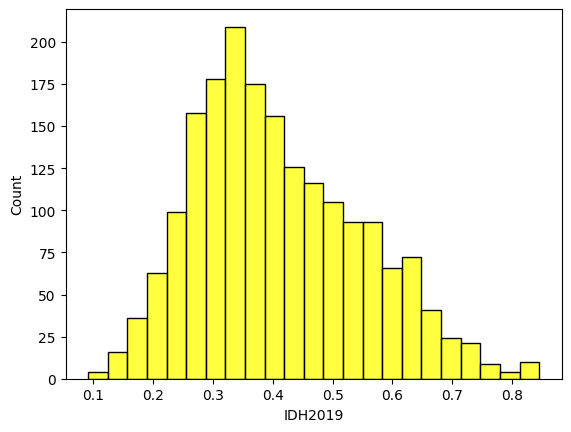

```python
#verificamos la data en un histograma
import seaborn as sea

sea.histplot(datadisMap.IDH2019, color='yellow')
```

```python
#!pip install mapclassify
```

```python
indice_lima = datadisMap[datadisMap.PROVINCIA == "LIMA"].index[0]
```

```python
indice_lima
```

```
1824
```

```python
primera_geometria_lima = datadisMap[datadisMap.PROVINCIA == "LIMA"].head(1)
```

```python
primera_geometria_lima
```

|  | DEPARTAMEN | PROVINCIA | DISTRITO | INSTITUCIO | geometry | provDist | Ubigeo | Departamento | Provincia | Distrito | Poblacion | Superficie | IDH2019 | Educ_sec_comp2019_pct | NBI2017_pct | Viv_sin_serv_hig2017_pct |
| --- | --- | --- | --- | --- | --- | --- | --- | --- | --- | --- | --- | --- | --- | --- | --- | --- |
| 1824 | LIMA | LIMA | SANTA ROSA | IGN | POLYGON ((-77.18443 -11.78003, -77.15744 -11.7... | LIMA+SANTA ROSA | 150139 | Lima | LIMA | SANTA ROSA | 20112 | 21.35 | 0.660577 | 67.61856 | 26.5 | 1.3 |

# CÁLCULO DE LOS NEIGHBORS DE LIMA PARA LA TRES OPCIONES

```python
#opción 1: The polygons that share borders:
```

```python
#!pip install libpysal
```

```python
from libpysal.weights import Queen, Rook, KNN

# rook
w_rook = Rook.from_dataframe(datadisMap,use_index=False)
```

```python
w_rook.islands
```

```
[89, 122]
```

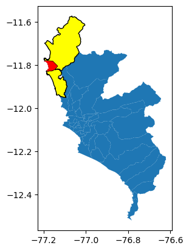

```python
# Cambiar "TACNA" por la provincia deseada, "LIMA"
base = datadisMap[datadisMap.PROVINCIA == "LIMA"].plot()
datadisMap.iloc[w_rook.neighbors[1824], ].plot(ax=base, facecolor="yellow", edgecolor="k")
primera_geometria_lima.plot(ax=base, facecolor="red")
```

```python
#opción 2: The polygons that share at least a point:
```

```python
# queen
w_queen = Queen.from_dataframe(datadisMap,use_index=False)
```

```python
w_queen.islands
```

```
[89, 122]
```

```python
datadisMap.iloc[w_queen.islands,:].explore()
```

Make this Notebook Trusted to load map: File -> Trust Notebook

[interactive chart not shown]

```python
len(w_queen.neighbors[1824
])
```

```
2
```

```python
datadisMap.iloc[w_queen.neighbors[1824
] ,]
```

|  | DEPARTAMEN | PROVINCIA | DISTRITO | INSTITUCIO | geometry | provDist | Ubigeo | Departamento | Provincia | Distrito | Poblacion | Superficie | IDH2019 | Educ_sec_comp2019_pct | NBI2017_pct | Viv_sin_serv_hig2017_pct |
| --- | --- | --- | --- | --- | --- | --- | --- | --- | --- | --- | --- | --- | --- | --- | --- | --- |
| 1826 | CALLAO | CALLAO | VENTANILLA | IGN | POLYGON ((-77.13521 -11.81782, -77.13516 -11.8... | CALLAO+VENTANILLA | 070106 | Callao | CALLAO | VENTANILLA | 402038 | 69.93 | 0.600316 | 69.088719 | 20.3 | 1.0 |
| 1870 | LIMA | LIMA | ANCON | IGN | POLYGON ((-77.06501 -11.57523, -77.06499 -11.5... | LIMA+ANCON | 150102 | Lima | LIMA | ANCON | 42124 | 285.45 | 0.668889 | 72.117976 | 21.7 | 1.1 |

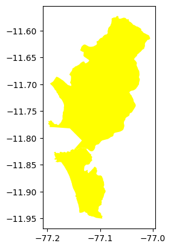

```python
datadisMap.iloc[w_queen.neighbors[1824
] ,].plot(facecolor="yellow")
```

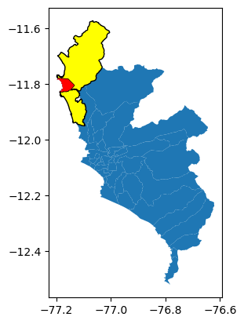

```python
base=datadisMap[datadisMap.PROVINCIA=="LIMA"].plot()
datadisMap.iloc[w_queen.neighbors[1824] ,].plot(ax=base,facecolor="yellow",edgecolor='k')
primera_geometria_lima.plot(ax=base,facecolor="red")
```

```python
#opción 3: NEIGHBORS MÁS CERCANOS
```

```python
# k=8 nearest neighbors
w_knn8 = KNN.from_dataframe(datadisMap, k=8)
```

```python
w_knn8.islands
```

```
[]
```

```python
w_knn8.neighbors[1824]
```

```
[1872, 1826, 1825, 1870, 1829, 1830, 1871, 1831]
```

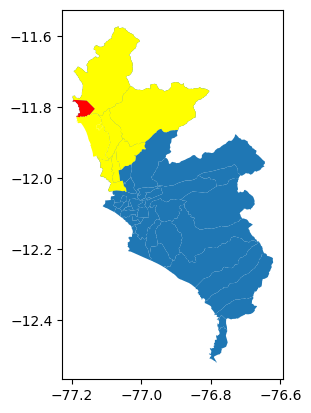

```python
base=datadisMap[datadisMap.PROVINCIA=="LIMA"].plot()
datadisMap.iloc[w_knn8.neighbors[1824],].plot(ax=base,facecolor="yellow")
primera_geometria_lima.plot(ax=base,facecolor="red")
```